# Wrangle Project

This is the act report of the wrangling WeRateDogs Twitter Data project.

```python
import numpy as np
import pandas as pd
import requests
import tweepy
import json
import matplotlib.pyplot as plt
import time
%matplotlib inline
```

```python
DF = pd.read_csv('Twitter_Archive_Master.csv')
DF.head()
```

|  | tweet_id | timestamp | source | text | expanded_urls | rating_numerator | rating_denominator | name | doggo | floofer | pupper | puppo | retweet_count | favorite_count |
| --- | --- | --- | --- | --- | --- | --- | --- | --- | --- | --- | --- | --- | --- | --- |
| 0 | 892420643555336193 | 2017-08-01 | <a href="http://twitter.com/download/iphone" r... | This is Phineas. He's a mystical boy. Only eve... | https://twitter.com/dog_rates/status/892420643... | 13 | 10 | Phineas | None | None | None | None | 8853 | 39467 |
| 1 | 892177421306343426 | 2017-08-01 | <a href="http://twitter.com/download/iphone" r... | This is Tilly. She's just checking pup on you.... | https://twitter.com/dog_rates/status/892177421... | 13 | 10 | Tilly | None | None | None | None | 6514 | 33819 |
| 2 | 891815181378084864 | 2017-07-31 | <a href="http://twitter.com/download/iphone" r... | This is Archie. He is a rare Norwegian Pouncin... | https://twitter.com/dog_rates/status/891815181... | 12 | 10 | Archie | None | None | None | None | 4328 | 25461 |
| 3 | 891689557279858688 | 2017-07-30 | <a href="http://twitter.com/download/iphone" r... | This is Darla. She commenced a snooze mid meal... | https://twitter.com/dog_rates/status/891689557... | 13 | 10 | Darla | None | None | None | None | 8964 | 42908 |
| 4 | 891327558926688256 | 2017-07-29 | <a href="http://twitter.com/download/iphone" r... | This is Franklin. He would like you to stop ca... | https://twitter.com/dog_rates/status/891327558... | 12 | 10 | Franklin | None | None | None | None | 9774 | 41048 |

Finallym I have reached the final stage. I have completed the Data Wrangle process (Gather, Assess, and Clean). Now, it is time to get some insights from the data.

##### First insight, I would like to know what are the most common names that people had for their dogs.

As you can see below: the top 10 popular dog names. And given the large data set, they are not substantially popular. There is a large number of missing names; data quality issue. But I have already cleaned more than the required number.

```python
DF.name.value_counts().head(10)
```

```
None       581
Lucy        11
Charlie     11
Oliver      10
Cooper      10
Lola         8
Penny        8
Tucker       8
Sadie        8
Winston      7
Name: name, dtype: int64
```

##### Second insight, I want to know if there is a correlation between favorite count and retweet count.

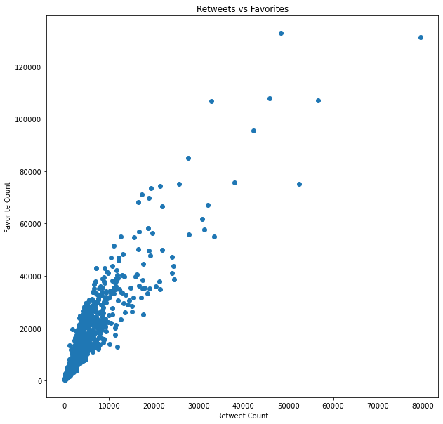

```python
plt.subplots(figsize=(10, 10))
plt.scatter(DF.retweet_count,DF.favorite_count)
plt.title('Retweets vs Favorites')
plt.xlabel('Retweet Count')
plt.ylabel('Favorite Count');
```

People tend to retweet the tweets they have favorited, which is common sense. Additionally, this is not a normal distribution of data. Most of the tweets counts reside below a threshold of both parameters.

##### Third insight, I want to know what is the relationship between retweet count and time

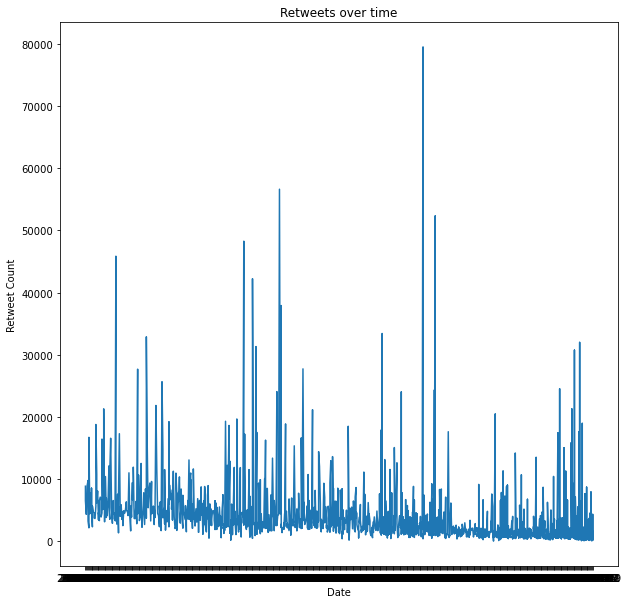

```python
plt.subplots(figsize=(10, 10))
plt.plot(DF.timestamp, DF.retweet_count)
plt.title('Retweets over time')
plt.xlabel('Date')
plt.ylabel('Retweet Count');
```

##### Fourth insight, I want to know what is the relation ship between favorite count and time.

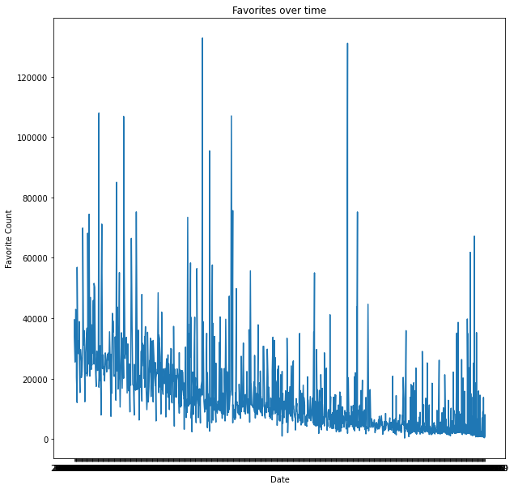

```python
plt.subplots(figsize=(10, 10))
plt.plot(DF.timestamp, DF.favorite_count)
plt.title('Favorites over time')
plt.xlabel('Date')
plt.ylabel('Favorite Count');
```